# BINA-FS23

VERTRAULICH!

Weitergabe oder Publikation dieser Abhandlung ohne schriftliche Zustimmung der Leuchter Software Engineering AG untersagt.

[figure not shown]

Abbildung 1: Titelbild (Quelle: https://it.telkomuniversity.ac.id)

**MSc Wirtschaftsinformatik, Business Intelligence & Analytics**

# Projektcontrolling und Forecast Dashboard für die Leuchter Software Engineering AG

### Hochschule Luzern (HSLU)

##### Studierende: Angelo Conconi, Michael Gaupp, Cédric Mory & Tobias von Rotz

Zürich, 16.06.2023

# Management Summary

**Situation & Entscheidungsbedarf**

Die Leuchter Software Engineering AG ist ein Softwareentwicklungsunternehmen, welches Individualsoftware sowie eigene Softwareprodukte im Bereich der automatisierten Dokumentenerstellung entwickelt. Hierbei verwendet die Leuchter Software Engineering AG für die Auftragsplanung und das Projektcontrolling das Issue-Tracking-Tool (vgl. Ticketing-System) Gemini vom Software-Hersteller Countersoft. Mittels Gemini werden die Aufwandschätzungen und Aufwandsrapportierungen für alle Projekte vorgenommen.

Im Rahmen einer internen Analyse zur Business-Excellence wurden Optimierungspotenziale im Projektcontrolling identifiziert. Insbesondere wurde der Bedarf an Indikatoren geäussert, welche Aussagen zu Risiken in Form von Budgetüberschreitungen und der Rentabilität von Projekten als auch Einschätzungen zur Performance von Entwicklerressouren ermöglichen. Hierfür bietet sich die Nutzung von Gemini an, da dieses in der zugehörigen Datenbank bereits, alle Daten die von Interesse sind, führt. Es gilt diesbezüglich das Gemini auf die Eignung, den Erfüllungsgrad der Nutzenpotenziale hin und die Verwendung für den Projektcontrolling-Zweck zu überprüfen.

**Vorgehen & Handlungsoptionen**

Für die vorliegende, offene Zielsetzung bietet es sich an, ein etabliertes Data-driven Decision making (DDDM) Framework zu verwenden, um den Informationsgewinn strukturiert-inkremetell, ergo teleologisch zu verfolgen. Hinsichtlich der gegebenen Situation wurde diesbezüglich auf das 5-Schritte-Modell "From Data to Decisions" von Chartered Professional Accountants Canada (CPA) zurückgegriffen, um die Eignung von Gemini zu evaluieren. Hierfür wurde vom Studierendenteam ein Setup im Sinne eines Testings nach dem Modell von CPA bereitgestellt. Gemäss Aufgabenstellung wurden lediglich die Schritte 1-4 erarbeitet.

In einem ersten Schritt wurden die Bedürfnisse auf Basis der Optimierungspotenziale überprüft und den zweckgemässen Informationsbedarf abgeleitet. Hierfür wurde ein Experteninterview mit einem Vertreter des Management Boards der Leuchter Software Engineering AG abgehalten. Anschliessend wurde eine objektive Zielsetzung erarbeitet, welche sinngemäss als Bewertungskatalog zur Eignungsprüfung des Geminis dient (vgl. Kapitel Step 1). Das Studierendenteam wurde im Auftrag der Leuchter Software Engineering AG mit der Aufgabe betraut, die Eignungsprüfung als vorliegende Abhandlung zum Gemini vorzunehmen.

In einem zweiten Schritt wurde die, gemäss erstem Schritt, relevante Datengrundlage beschafft. Hierbei galt ein besonderer Fokus der Datenmanipulation und späteren -analyse der Datensets. Nach anfänglichen Erschwernissen setzte das Studierendenteam einen SQL-Server in Azure mit dem Back-Up der produktiven Gemini-Datenbank auf, welche als Datenquelle dient (vgl. Kapitel Step 2). Abklärungen zu weiteren Datenquellen wurden unternommen, als weitere Datenquelle kam das Enterprise-Ressourcing-Planning-Systems der Leuchter Software Engineering in Frage, welches allerdings infolge von Vertraulichkeitsthemen nicht verwendet werden konnte.

In einem dritten Schritt wurden die gegebenen Daten hinsichtlich Relevanz und Eignung zur Zielerfüllung überprüft. Im Weiteren stand die spätere Belastbarkeit der Daten im Fokus. Diesbezüglich wurden umfangreiche Analysen vorgenommen, um von gegebenen Daten, auf den zweckgerichteten Informationsbedarf der Leuchter Software Engineering AG zu schliessen. Weitere Kalkulationen wurden diesbezüglich notwendig (vgl. Kapitel Step 3).

In einem vierten Schritt wurden die analysierten, konkretisierten und aufbereiteten Daten visuell dargestellt. Dabei wurde in Rücksprache mit der Leuchter Software Engineering ein Cockpit in Form eines Microsoft PowerBI Dashboardd erstellt, welches ebenfalls auf demselben Applikationsserver (vgl. SQL-Server) installiert wurde (vgl. Kapitel Step 4).

**Nächste Schritte**

Im Anschluss an die Re-Evaluation der Liefergebenisse wird der Leuchter Software Engineering AG empfohlen, den Mitteleinsatz im Live-Betrieb zu begleiten und kontinuierlich auf die langfristige Zielerreichung hin zu überprüfen.

# **Allgemeine Informationen**

**Zweck des vorliegenden Notebooks**

Das vorliegende Notebook wurde im Rahmen des Moduls Business Intelligence & Analytics (BINA) des Studiengangs Master of Science in Wirtschaftsinformatik angefertigt. Das Notebook dient dazu die Case Study für den dafür erforderlichen Lernnachweis der Studierenden aus dem Modul zu dokumentieren.

**Geltungsbereich**

Das vorliegende Notebook ist auf Basis des Auftragsbeschriebs erarbeitet worden. Die dem Notebook zu entnehmenden Gegenstände bzw. Inhalte hiervor wurden, basierend auf den geführten Interviews mit der Geschäftsleitung der Leuchter Software Engineering AG umgesetzt. Somit ist die Belastbarkeit der Inhalte in der Praxis zu überprüfen. Folglich hat das Notebook bis auf Weiteres weder Gültig- noch Anwendbarkeit.

**Adressaten**

Das vorliegende Dokument richtet sich einzig an den Dozierenden des Moduls Business Intelligence & Analytics. Namentlich ist dies:

− Herrn Dr. phil. nat. Daniel Benninger

Die Autoren dieses Notebooks sind sich darüber im Klaren, dass die vorliegende Arbeit als auch dessen Inhalten und/oder Teilen davon sowie Artefakte auf ungeprüften Aussagen und/oder Annahmen beruhen können (separat ausgewiesen).

**Autoren**

| Angelo Conconi | Michael Gaupp | Cédric Mory | Tobias von Rotz |
| --- | --- | --- | --- |
| Hochschule Luzern | Berner Fachhochschule | Hochschule Luzern | Hochschule Luzern |
| Sternenriedplatz 1 | Wankdorffeldstrasse 75 | Schlossbergstrasse 14 | Unterdorfstrasse 59 |
| 6048 Horw | 3014 Bern | 6312 Steinhausen | 8124 Maur |
| +41 79 542 66 56 | +41 78 648 48 51 | +41 79 665 28 02 | +41 79 710 65 66 |
| angelo.conconi@stud.hslu.ch | michael.gaupp@students.bfh.ch | cedric.mory@stud.hslu.ch | tobias.vonrotz@stud.hslu.ch |

# **Einleitung**

**Ausgangslage**

Die Leuchter Software Engineering AG (SE) wurde 2012 gegründet und ist in der Stadt Luzern ansässig. Das Unternehmen ist im Bereich der Softwareentwicklung tätig und bedient ihre Kunden mit individuellen, massgeschneiderten Softwarelösungen als auch mit ihren Software Produkten wie "Docugate" und "Signgate" (Leuchter AG, 2023).

Für die Administration und das Controlling aller Aufträge nutzt die Leuchter Software Engineering AG ein Issue-Tracking-Tool namens Gemini des Software-Herstellers Countersoft. In Gemini werden insbesondere die Aufwandschätzung und Aufwandsrapportierung innerhalb von Issues für: Neuentwicklungen, Software-Releases, Nachträgen und Garantiearbeiten erfasst und darin abgebildet.

**Anstoss zur Untersuchung**

Im Rahmen einer internen Analyse in puncto Business-Excellence wurden Optimierungspotenziale, insbesondere im Projektcontrolling, identifiziert. Hierbei wären Indikatoren wünschenswert, welche die Rentabilität von Projekten aufzeigt und die Einschätzungen zu der Performance von Entwicklerteams ermöglicht.  
Zwar werden im Gemini breite Geschäftsdaten genutzt; diesbezüglich stellt Gemini auch umfangreiche Funktionalitäten für die Geschäftstätigkeit bereit. Diese Daten werden aktuell aber vorwiegend für die administrativen Belange im operativen Projektmanagement genutzt. Entsprechend sollen die Daten aus Gemini (ggfs. in Kombination mit dem weiteren Tool-Set der SE) zur Nutzung im Projektcontrolling überprüft werden.

**Grundlegende Zielsetzung**

Die SE beabsichtigt übergeordnet, Informationen zu den Arbeitspaketen (Wording Gemini: Issues, sinngem. Aufträge) weiterführend zu analysieren, um frühzeitige Projektrisiken in Hinsicht auf Budget- oder Terminüberschreitungen erkennen zu können. Hierzu sollen, sofern möglich, Auswertungen auf Projekt- und Mitarbeiter-Ebene visualisiert werden. Optional soll überprüft werden, ob Machine Learning für das Reporting verwendet werden kann und daraus resultierende Forecasts auf Projektebene, die Arbeit der Projektleiter erleichtern kann. Die Forecasts sollen zu einer qualitativ-besseren Planung von Projekten beitragen und so die Ressourcenplanung der Mitarbeitenden auf Projekte optimieren.

Die Zielsetzung bedarf einer weiterführenden Überprüfung, um teleologische Lieferobjekte bzw. Artefakte bereitstellen zu können.

**Methodik**

Auf Basis der grundlegenden Zielsetzung bietet es sich an, ein am Markt etabliertes Framework für data-driven-decision-making (DDDM) zu nutzen. Hierfür wird auf das Framework "From Data to Desicions" von Chartered Professional Accountants Canada (CPA) zurückgegriffen (Marr, 2020). Das Framework eignet sich ideal für die Ausgangslage des Vorhabens und führt in fünf Schritten an die datengetriebene Entscheidungsfindung, wie sie für die SE nützlich wäre, heran.

*Für das Projektvorhaben werden aus zeitlichen Einschränkungen lediglich die Schritte 1 - 4 durchgeführt.*

**Alternativen**

DDDM ist ein aktuelles, mit grossem Interesse, verfolgtes Forschungsgebiet. Nebst dem Framework von CPA stehen weitere, ähnliche Frameworks wie z. B. der DDDM-Guide von tableau bereit. (tableau, 2023). Diese sind sich in den Ansätzen sehr ähnlich und unterscheiden sich vorwiegend in der Anzahl Schritte. Da kein signifikanter Mehrwert durch dieses Framework besteht, wird diesbezüglich das DDDM-Framework von CPA weiterverfolgt.

**Vorgehen**

Für das Vorhaben wurde das induktive Vorgehen gemäss Framework gewählt. Dieses verfolgt die folgenden Schritte.

**Step 1 - "Defining objectives and information needs"**

Im ersten Schritt erfolgt eine differenzierte Betrachtung der grundlegenden Zielsetzung. Hierbei liegt der Fokus auf der präzisen Definition von Zielen und den erforderlichen Informationen. Dieses Vorgehen gewährleistet, dass die richtigen Daten erhoben werden und daraus relevante Informationen abgeleitet werden können. Dadurch wird eine adäquate Erfüllung der Anforderungen der SE angestrebt.

**Step 2 - "Collecting data"**

Im nächsten Schritt erfolgt die Datensammlung. Dabei ist es von grosser Bedeutung, relevante und valide Daten zu berücksichtigen. Des Weiteren werden die quantitativen Aspekte der Daten, wie beispielsweise ihre Verfügbarkeit und Menge, sorgfältig beachtet.

**Step 3 - "Analyzing data"**

Im dritten Schritt erfolgt die Datenanalyse, welche darauf abzielt, die Zuverlässigkeit und den damit verbundenen Erkenntnisgewinn zu gewährleisten. Da die vorliegenden Daten Projekte oder Issues betreffen, eignen sich zur Anwendung eher quantitative Analysemethoden wie Data Mining oder Regression. Die konkrete Methode wird nach der Datensammlung festgelegt.

**Step 4 - "Presenting information"**

Im vierten Schritt werden die aus den Daten abgeleiteten Informationen präsentiert, um den spezifischen Nutzungsanforderungen der SE gerecht zu werden.

# **Step 1 - Defining objectives and information needs**

In diesem Schritt wurde die ursprüngliche Zielsetzung der SE überprüft. Dabei lag der Fokus auf der Neubewertung der bestehenden Zielsetzung hinsichtlich der Definition und des tatsächlich erforderlichen Informationsbedarfs. Die Studierenden haben dazu ein Interview mit Andreas Imboden, dem Projektleiter und Leiter von Docugate bei SE durchgeführt. Die gewonnenen Erkenntnisse wurden wie folgt zusammengefasst:

**Informationsbedürfnisse** *(→"Top-level information needs")*  
vgl. Einleitung; übergeordnete Zielsetzung.

**Informationsbedarfsteller** *(→"Identifying who needs the information")*  
Konkrete Bedarfssteller lassen sich in die folgenden Rollen zusammenfassen:

– Management (Geschäftsleitung der SE)

– Projektleiter

**Abgeleiteter Informationsbedarf** *(→"Clarifying what questions they want answered")*

Auf Basis des Interviews wurde der Informationsbedarf thematisch segmentiert und abgeleitet:

– Projektrisiken

∘ Projektrisiken: Gemini als Standardsoftware ist in seinen Schnittstellen limitiert, verfügt daher über wenige Analysetools und Projektrisiken können somit nicht optimal überwachet werden. Die Projektrisiken gilt es über eine zu definierende Metrik mittels vorhandener Daten abzuschätzen. Als Projektrisiken genügen die Angaben nach dem Projektstand, d. h. Vergleich der rapportierten zu geschätzten Stunden (IST-Stunden zu SOLL-Stunden). Ein quantifizierter Indikator ist nicht notwendig, einzig soll eine visuelle Hilfestellung gegeben sein, die klar und verständlich aufzeigt, wie es um die Projekte steht. Dabei soll der visuelle Indikator auf Stufe der Projekte greifen, einzelne Zeitbuchungen sind für die Betrachtung nicht relevant.

– Projektcontrolling

∘ Durchlaufzeit: Derzeit bietet Gemini keine Möglichkeit die effektiv benötigte Durchlaufzeit der Issues zu betrachten. Benötigt werden diese Angaben speziell für den Servicedesk. Hier werden gemäss Service Level Agreement mit den Kunden Reaktionszeiten definiert, welche bereits ausgewiesen werden in Gemini. Jedoch ist die effektive Entstörungszeit nicht ersichtlich. Indes ist es erwünscht den Kunden in den jährlichen Key Account Gesprächen über die Performance der Dienstleistung der SE zu rapportieren. Die Durchlaufzeit soll als Durchschnittswert für die individuellen Kunden aufgezeigt werden können. Die Durchlaufzeit muss für das Management eingesehen werden können.

∘ Performance: Die Perfomance soll nach Projekten und Mitarbeitende aufgeschlüsselt werden können.

– Projekte: Die Leistungsfähigkeit bzw. Effizienz der Projekte (Issues) soll sichtbar gemacht werden. Hierfür genügt eine Gegenüberstellung der geschätzten zu den angelaufenen Zeiten. Die Leistungsfähigkeit soll auf Stufe der Projekte dem Management als auch den Projektleitern aufgezeigt werden.

– Mitarbeiter: Die Leistungsfähigkeit einzelner Mitarbeitenden soll sichtbar gemacht werden. Hierfür genügt eine Gegenüberstellung der geschätzten zu den angelaufenen Stunden über die bearbeitenden Projekte der Mitarbeitenden. Die Leistungsfähigkeit auf Stufe Mitarbeitenden soll nur für das Management zur Verfügung stehen.

– Forecasts:

Mit Einsatz von Machine-Learning sollen die bereits aufgelaufenen Stunden mit den noch verbleibenden Stunden verglichen werden und aufgrund der Zeitreihe eine Aussage über die noch umzusetzenden Issues machen zu können.

**Zielsetzung**

In untenstehender Tabelle wurde die spezifizierte Zielsetzung auf Basis vorangegangener Ableitung ausgewiesen.

| ID | Ziel | Zielbeschreibung | Informationsbedarfssteller | Granularität | potenzielle Indikatoren |
| --- | --- | --- | --- | --- | --- |
| Z1 | Durchlaufzeit Projekt | Die Durchlaufzeiten im Servicedesk sollen eingesehen werden können | Management, Projektleiter | Kunde | Datum<sub>ENDE</sub> – Datum<sub>START</sub> in [d] |
| Z2 | Performance Mitarbeitende | Die Performance pro Mitarbeiter soll eingesehen werden können | Management | Projekte, Versionen | t<sub>IST</sub> – t<sub>SOLL</sub> in [h] |
| Z3 | Performance Projekte | Die Performance pro Projekt soll eingesehen werden können | Management, Projektleiter | Versionen, Komponenten | t<sub>IST</sub> – t<sub>SOLL</sub> in [h] |
| Z3.1 | Budgetüberschreitung | Die Budgetüberschreitung pro Projekt soll visuell dargestellt werden | Management | Versionen, Komponenten | t<sub>IST</sub> > t<sub>SOLL</sub> in [h] |
| Z4 | Forecasts | Der Forecast soll aufgrund des aktuellen Stand des Projektes darstellen, ob ein Projekt erfolgreich (In-Time, In-Budget) abgeschlossen werden kann | Management, Projektleiter | Projekt, Versionen | t<sub>IST</sub> > t<sub>SOLL</sub> in [h] & Projekt<sub>ENDE</sub> – Projekt<sub>START</sub> |

Tabelle 1: Zielsetzung

*Erweiterte Anforderungen gemäss Zielsetzung:*

*Die Leuchter Software Engineering AG bittet um die Verwendung eines eigenständigen Tools, welches die Daten während Geschäftstätigkeit zum Gebrauch nutzbar macht. Das Tool soll professionell genutzt werden und nach Möglichkeit in der Leuchter Domäne eingebettet werden können. Vorschläge sind mit der Leuchter Software Engineering AG abzustimmen.*

# **Step 2 - Collecting data**

Im vorliegenden Step wurde die Datenbeschaffung vorgenommen. Die Datensammlung erfolgt auf Basis des vorangehenden Kapitels (vgl. Step 1) und dient zum Zweck, eine Datengrundlage für die Deckung des Informationsbedarfs und des weiteren Vorhabens bereitzustellen.

**Datenquellen**

Der Abhandlung liegen Daten aus dem Gemini der SE zu Grunde, welche u. a. Informationen über Projekte (Issues), Mitarbeitenden, Aufwände (geschätzt und effektiv) und weitere projektbezogene Daten enthält. Sie sind in Form der Gemini zugehörigen Datenbank zu entnehmen. Hierfür stellte die SE den Studierenden ein Gemini-Database-Backup aus der produktiven Umgebung in Form einer Backup-Datei (.bak Format) zur Verfügung.

Folglich bildet das Gemini produktiv Backup (sog. SE_Gemini_Prod) die Primärquelle der vorliegenden Abhandlung.

**Prüfung ergänzender Quellen** *(→"Supporting internal data with external data")*  
In einem nächsten Schritt wurde überprüft, ob dem SE_Gemini_Prod ergänzende Quellen zur Verfügung gestellt werden, um den Datengehalt anzureichern und für sinnvoll für den Nutzungszweck ergänzen zu können.

Hierzu bot es sich an auf die Enterprise Resource Planning Software (Sage 100) und deren Daten der Leuchter Software Engineering AG zurückzugreifen. Auf Grundlage dieser wäre es möglich, die Projekte mit monetären Daten der verrechneten Stunden zu quantifizieren.

Weiter wird jeweils ergänzend zu den Projekten ein Planning Dokument erstellt. Dieses beinhaltet relevante Informationen zum Terminplan sowie den Projektkosten. Da der Terminplan ausschliesslich in Textform in einem Word Dokument vorhanden ist, eignen sich diese Daten nicht für eine kohärente Auswertung. Aufgrund dieser Tatsache, ist eine Weiterverfolgung von Z4 aktuell nicht möglich, da der Terminplan nicht für die Auswertung verwendet werden kann.

Desweiteren konnten keine ergänzenden sinnvollen externen Quellen für die vorliegende Datenbasis ermittelt und herbeigezogen werden.

**Datenprüfung**  
*(→"Considering data ownership"; →"Considering data privacy"; →"Balancing structured data with unstructured data")*

Als Nächstes wurde eine Klärung zu den Daten hinsichtlich Eigentum und Privatsphäre vorgenommen.

Die Daten sind im Eigentum der SE mit den entsprechenden Eigentums- und Besitz-Rechten behaftet. Nach Rücksprache mit der SE handelt es sich bei beiden Datensätzen um sensible Daten. Die Datenquelle des ERP-Systems Sage 100 konnte aufgrund einer Verwendung aus Online-Diensten und Bedenken aus Sicht der Vertraulichkeit (u. a. Einblicke über Umsatzzahlen, Gewinn) nicht ausgehändigt noch offengelegt werden. Die Sekundärquelle konnte daher im weiteren Vorhaben nicht berücksichtigt werden. Folglich bezieht sich die vorliegende Abhandlung lediglich auf die primäre Datenquelle SE_Gemini_Prod ohne ergänzende, externe Datensätze.

Die vorliegenden Datensätze sind weitestgehens als strukturiert zu bezeichnen, sie basieren auf einer relationellen Datenbank. Unstrukturierte Daten (im Sinne von Metainformationen) stehen aus dem Interview bereit, beziehen sich aber nicht effektiv auf den Datensatz und können resultativ schlussgefolgert werden. Daher scheint eine Nivellierung durch eine fehlende Bezugsbasis, zwischen unstrukturierten und strukturierten Daten für die vorliegende Abhandlung, als nicht gegeben.

**Datenübersicht & Klassifikation** *(→"Identifying data collection formats")*

Die vorliegenden Daten der Primärquelle wurden aufbereitet sowie klassifiziert. Die entsprechenden Informationen sind der untenstehenden Tabelle in Bezugnahme zur Management Accounting Guidline (vgl. Marr, B. 2020, S. 14) zu entnehmen.

|  | Merkmal | Beschreibung |
| --- | --- | --- |
| Format | .bak File (Backup SQL-DataBase Dump) |  |
| Grösse | 38'256,25 MB |  |
| Anzahl Tabellen | 141 |  |
| Dimension | zweidimensional |  |
| Typus | strukturierte Daten |  |
| Sammlungsformat | Aktivitätsdaten |  |
| Aktualität | Snapshot vom 02.04.2023 |  |
| Zeitspanne | 2005-04-14 13:58:44.037 - 2023-04-02 06:35:21.547 |  |

Tabelle 2: Datenübersicht & Klassifikation

**Verantwortlichkeiten** *(→"Decide who is responsible for collecting the data.")*

Die Daten werden initial durch die SE für die Tests bereitgestellt. Das Studierendenteam verantwortet dabei einmalig die Datenintegration, -manipulation, -aufbereitung und entsprechende Darstellung des Test-Systems. Verlaufen die Tests für die SE zufriedenstellend, stellt das Studierendenteam Konfigurationsdateien, Quellcodes (Code-Snippets von Querries & Skriptsprachen) dem Auftraggeber für die Anwendung bereit. Die Leuchter Software Engineering AG verantwortet selbstständig die Transition vom Test- zum Live-Betrieb auf Basis der IST-Daten (tatsächliche produktiv Daten) mit gegebener Hilfestellung.

**Planung der Datenbeschaffung** *(→"Planning data collection")*

In einem nächsten Schritt galt es die Datenbeschaffung zu planen. Hierfür wurden die untenstehenden Schritte notwendig:

1. Back-Up Daten via Datentransfer mit der SE koordinieren und erhalten
2. Back-Up in bearbeitbares Format umwandeln (Konvertierung bak.-Format)
3. Bearbeitbares Format laden, um Analyse & Manipulation vorzunehmen
4. Zielkonforme Bearbeitung & Aufbereitung der Daten (vgl. Step 1, Marr, B. 2020)
5. Visualisierung der aufbereiteten Daten (vgl. Step 4, Marr, B. 2020)

In den fortfolgenden Unterkapiteln wird gemäss obiger Auflistung, der Prozess der Datenbeschaffung erklärt und soll den Lesenden eine Erläuterung hierzu geben.

**Hinweis**

Die Datenbeschaffung *(vgl. Planung der Datenbeschaffung)* gestaltete sich herausfordernd, weshalb Workarounds erforderlich wurden, um die Daten zwecksgemäss beschaffen und folglich verwenden zu können. Die Erschwernisse und Workarounds wurden je Schritt separat ausgewiesen.

**1. Erhalt Back-Up Daten**

Ursprünglich sollten die Daten über einen direkten FTP-Download, ab Server der Leuchter, beschafft werden. Hierzu setzte der Studierende Angelo Conconi *(Anm. ebenfalls Mitarbeiter der Leuchter Software Engineering AG)* einen FTP-Server in der Leuchter Software Engineering AG Umgebung in Stand.

Erschwernisse:

Der FTP-Transfer wurde mehrmals gestartet; aufgrund von Verbindungsproblemen konnte der Download *(Anm. 4 Versuche zw. 05.04.2023 - 07.04.2023)* nur bis teilweise 60% erfolgen und wurde jeweils vom System abgebrochen. Die Probleme konnten nicht gänzlich eruiert und behoben werden.

Workaround:

In Absprache mit der Leuchter Software Engineering AG wurde ein Transfer über einen FTP-Anbieter in Erwägung gezogen *(Dritt-Dienst)*. Gemäss den erweiterten Anforderungen wurde hierfür auf die FTP-Lösung swisstransfer des schweizerischen Informatikdienstleisters infomaniak zurückgegeriffen. Die Evaluation erfolgte aufgrund der AGB von infomaniak insb. der Datenhaltung innerhalb der Schweiz. Der Download verlief erfolgreich; Link: https://www.swisstransfer.com/d/495d6f31-74d0-4910-83de-ef4b059ad3fc *(Gültig bis 06.05.2023)*.

Das Gemini_Prod_Backup im .bak-Format wurde im Anschluss lokal auf den Endgeräten der Studierenden gespeichert.

**2. Umformatierung der Daten**

Da das Jupyter Notebook gehostet via Google Colab über die Laufzeit *(engl. Runtime)* von Pyhton und damit über die entsprechende Script-Engine verfügt, wurde anfangs auf eine Einbettung der Daten angestrebt.

In Bezug auf die Umformatierung wurde entsprechend nach Python-Libraries gesucht, welche eine Umformatierung von .bak nach .csv ermöglichten. Nach einer Internet-Recherche wurde das Paket poster3 ermittelt, welches die entsprechenden Funktionen bereitstellen konnte. Untenstehend ist das Bash-Script für die Installation der Library sowie Umformatierung zu entnehmen.

Initial wurde eine Prüfung der Runtime-Umgebung des vorliegenden Jupyter Notebooks vorgenommen (vgl. Code-Snippet 100), um die richtigen Methoden für das Scripting zu verwenden. Zum aktuellen Zeitpunkt der Abhandlung verfügte das Jupyter Notebook über die Versionen:

Python 3.10.11

Ubuntu 20.04.5, Longtime-Support (LTS))

```python
# Code-Snippet 100
# Sprache: python / Bash-Script
# -----------------------------------------------------------------------------------------------------

# Prüfung der Runtime-Version
!python -V
# Prüfung der Linux OS-Version für korrekte Installationsmethode der Libraries & Packages
!lsb_release -a
```

```
Python 3.10.11
No LSB modules are available.
Distributor ID:	Ubuntu
Description:	Ubuntu 20.04.5 LTS
Release:	20.04
Codename:	focal
```

Im nächsten Schritt wurde poster3 installiert (vgl. Code-Snippet 110).

```python
# Code-Snippet 110
# Sprache: python / Bash-Script
# -----------------------------------------------------------------------------------------------------

# Daten-Bereitstellung (Umformatierung .bak nach .csv Datei-Format)
# Installation der poster3 Library
# !!! aus Sicherheitsgründen wurden keine Datei-Verzeichnisse angegeben (s. Erschwernisse unten) !!!
!pip install poster3

  from poster.encode import multipart_encode
  from poster.streaminghttp import register_openers
  import urllib2

  # Register the streaming http handlers with urllib2
  register_openers()

  # Use multipart encoding for the input files
  datagen, headers = multipart_encode({ 'files[]': open('example.bak', 'rb')})

  # Create the request object
  request = urllib2.Request('https://www.rebasedata.com/api/v1/convert', datagen, headers)

  # Do the request and get the response
  # Here the BAK file gets converted to CSV
  response = urllib2.urlopen(request)

  # Check if an error came back
  if response.info().getheader('Content-Type') == 'application/json':
      print response.read()
      sys.exit(1)

  # Write the response to /tmp/output.zip
  with open('/tmp/output.zip', 'wb') as local_file:
      local_file.write(response.read())

  print 'Conversion result successfully written to /tmp/output.zip!'
```

Erschwernisse:

Da die poster3-Library eine API von rebasedata nutzt, folglich die Datenhaltung, -verarbeitung und -speicherung der sensitiven Daten unklar sind, wurde von dieser Variante abgesehen, um die erweiterten Anforderungen der Leuchter Software Engineering AG nicht zu verletzen *(CSV=Klartext!)*.  
Workaround:

Nach Rücksprache mit der Leuchter Software Engineering AG durften die Studierenden innerhalb einer geschützten Umgebung *(Microsoft Azure)* einen SQL-Server aufsetzen. Die .bak-Datei wurde darin wiederhergestellt. Fortan wurde auf der Azure-SQL-DB-Instanz gearbeitet. Das Aufsetzen erwies sich, nach anfänglichen Problemen aufgrund fehlerhafter Erstinstanzerstellung Microsoft-seitig (Server nicht ansprechbar), als erfolgreich.

**3. Laden der Daten, Vorbereitung Daten-Analyse & -Manipulation**

Erneut wurde eine Vorgehensmethode, welche auf der gegebenen Runtime des Jupyter Notebooks basiert, zur Anbindung an den SQL-Server und dem Laden der Daten gewählt. Nach einer Internet-Recherche wurde die Pakete msodbcsql17 & pyodbc ermittelt, welche die entsprechenden Funktionen bereitstellen konnten. In untenstehenden Code-Snippets sind die Installationen der notwendigen (Treiber-)Libraries zu entnehmen, als auch ein Versuch der Datenauslesung.

In einem ersten Schritt wurden zur Anbindung zum SQL-Server, der von Microsoft offizielle pyhton-ODBC Treiber installiert (Code-Snippet 200).

```python
# Code-Snippet 200
# Sprache: python / Bash-Script
# -----------------------------------------------------------------------------------------------------

# Daten-Bereitstellung (Laden der Daten, Vorbereitung Daten-Analyse & -Manipulation)
# Installation des offiziellen Microsoft SQL-Treibers
# Anbindung der SQL-Database über entsprechende SQL-Funktionalitäten

!curl https://packages.microsoft.com/keys/microsoft.asc | apt-key add -
#Download appropriate package for the OS version
#Choose only ONE of the following, corresponding to your OS version

# Gemäss Prüfung handelt es sich bei der Colab-Runtime um ein Ubuntu 20.04
!curl https://packages.microsoft.com/config/ubuntu/20.04/prod.list > /etc/apt/sources.list.d/mssql-release.list
!sudo apt-get update
!sudo ACCEPT_EULA=Y apt-get install msodbcsql17

# optional: for bcp and sqlcmd
!sudo ACCEPT_EULA=Y apt-get install mssql-tools
!echo 'export PATH="$PATH:/opt/mssql-tools/bin"' >> ~/.bash_profile
!echo 'export PATH="$PATH:/opt/mssql-tools/bin"' >> ~/.bashrc
!source ~/.bashrc

# optional: for unixODBC development headers
!sudo apt-get install unixodbc-dev
```

In einem nächsten Schritt musste zusätzlich das Paket pyodbc installiert werden, um die Verbindungseinstellungen für den SQL-Treiber vorzunehmen und die entsprechende SQL-Connection zu parametrieren und sich danach mit dem SQL-Server verbinden zu können (vgl. Code-Snippet 210). Dieses Paket wurde nicht wie angenommen der Python-Runtime-Bibliothek hinzugefügt. Deshalb hatte die explizite Installation des pyodbc separat zu erfolgen.

Um zu gewährleisten, dass die Datenbeschaffung funktioniert, wurde versuchshalber ein einfacher Daten-Request *SELECT (read)* initialisiert, im Sinne einer Verifikation von Verbindung und dem Laden der Daten. Hierbei wurde auf die Tabelle "gemini_issues" die ersten 100 Einträge zurückgegriffen (vgl. Code-Snippet 210; cursor.execute(...)).

```python
# Code-Snippet 210
# Sprache: python / Bash-Script
# -----------------------------------------------------------------------------------------------------

# Daten-Bereitstellung (Laden der Daten, Vorbereitung Daten-Analyse & -Manipulation)
# Verbindungsaufbau zum SQL-Server (BINA-FS der Leuchter Software Engineering AG)
!pip install pyodbc

import pyodbc
print(pyodbc.drivers())
conn = pyodbc.connect('Driver=ODBC Driver 17 for SQL Server;'
                      'Server=20.56.61.152;'
                      'Database=SE_Gemini_Prod;'
                      'UID=adm-bina-bi;'
                      'PWD=Frühling2023;')

cursor = conn.cursor()
cursor.execute('SELECT top 100 * FROM gemini_issues')

for i in cursor:
    print(i)
```

Erschwernisse:

Die vorangegangene Anbindung zum SQL-Datenbank-Server der SE erwies sich als erfolgreich. Um der erweiterten Anforderungen der Leuchter Software Engineering AG Sorge zu tragen, wurde diese Methode für die weitere Datenbearbeitung der Auftraggeberschaft vorgestellt. *(vgl. Step 1 - Zielsetzung, erweiterte Anforderungen)*. Hierbei befand die Leuchter Software Engineering AG eine Lösung über Python als machbar, jedoch im Geschäftsalltag als impraktikabel. Die Begründung lag einerseits durch das Nicht-Verwenden von Linux-Umgebungen *(ergo dem fehlenden Linux-Mitteleinsatz sowie -Tools; keine Einbettung im operativen Business)*, als auch dem Mangel entsprechender Linux-Kompetenzen der Mitarbeitenden *(in Bezug zur späteren Transition, vgl. Step 2 - Verantwortlichkeiten)*. Im Weiteren enthalten einige Tabellen mehr als 46'000 Zeilen *(Tabelle gemini_issues)*, welches die Runtime des Jupyter Colab Notebooks regelmässig zum abstürzen bringt. Das Studierendenteam wurde angehalten, eine Alternative für die Datenmanipulation und -bearbeitung auf Basis einer gängigen, sich in der Microsoft-Umgebung integrierenden Lösung bereitzustellen.  
Workaround:

Nach Rücksprache mit der SE wurde der Wunsch geäussert, direkt auf der SQL-Datenbank in Azure als auch hinsichtlich der Visualisierung der SQL-Daten auf PowerBI (Microsoft Portfolio) zu arbeiten. Das Studierendenteam willigte diesbezüglich ein und verfolgte den Ansatz, rein auf dem gestellten Azure-Server zu arbeiten als auch entsprechende Lösungskonzepte auf dieser Basis bereitzustellen.

```python
# Code-Snippet 300
# Verbindungseinstellungen; keine Scripting-Language
# -----------------------------------------------------------------------------------------------------

# Remote-Desktop-Verbindung
# Bitte beim Studierendenteam anfragen, um Server hochzufahren (auto-shutdown)

# IP: 20.56.61.152:3389
# Benutzername: adm-bin (Hinweis! womöglich ".\" voransetzen (Suffix), um sich nicht mit Domäne anzumelden)
# Passwort: Frühling2023
```

# **Step 3 - Analyzing Data**

Im vorliegenden Step 3 wurden die Daten analysiert. Zu Beginn wurde das Datenset untersucht, um auf die, für die Zielsetzung, relevanten Daten zu schliessen. In Ergänzung dazu, wurde eine Vollständigkeitsprüfung vorgenommen, um sicherzustellen, dass sämtliche Attribute bereitgestellt wurden oder durch das Studierendenteam bereitzustellen sind, welche eine Belastbarkeit der Datengrundlagen für die entsprechende Zielsetzung (vgl. Tabelle 1) garantieren. Im Anschluss daran, wurden die relevanten Daten zusammengeführt, analysiert und weiter prozessiert. Die Bearbeitung des Datensets wird direkt in der Datenbank des SQL-Servers vorgenommen; als Ergänzung dazu wurden die SQL-Queries portiert und für das vorliegende Jupyter Notebook als Code-Snippet bereitgestellt.

**Untersuchung der Datenrelevanz**

Gegeben ist das Back-Up der, zum produktiven Gemini, zugehörigen Datenbank. In einem ersten Schritt wurden die 141 Tabellen nach relevanten Informationen, auf Basis der Zielsetzung, zum Risikomanagement und Projektcontrolling hin, geprüft (vgl. Tabelle unten).

[output not shown]

Tabelle 3: Übersicht Tabellen in DB

In Bezugnahme zur Zielsetzung (vgl. Tabelle 1) konnten die wesentlichen Informationen in den aufgeführten Tabellen (vgl. Tabelle 3) identifiziert und deren Daten eingegrenzt werden:

gemini_components

gemini_issues

gemini_issuecomponents

gemini_issuestatus

gemini_issueressources

gemini_projects

gemini_users

gemini_versions

Die wichtigste Tabelle bildet die *gemini_issues*, welche elementare Informationen zu den Auftragspakete bereistellt. Sie enthält die relevanten kaufmännischen und administrativen Informationen (z.B. geschätzte Zeiten, gebuchte Zeiten, zugewiesene Mitarbeiter) für die Issues (Tickets/Aufträge) und kann mehrere Komponenten (Logische Aufteilung der Applikation) enthalten. Sie dient ebenfalls als Referenz zur Zusammenführung der Daten.

Die Begründung für die relevanten Daten wurde jeweils in untenstehenden Tabellen ausgewiesen.

|  | Tabelle | Attribut | Begründung der Relevanz | Ziel-Relevanz |
| --- | --- | --- | --- | --- |
| gemini_components | componentname | Name der Komponente des Projekt (Component zugehörig zu Projekt) | Z1, Z2, Z3, Z3.1 |  |
| gemini_components | componentdesc | Beschreibung der Komponente (Component zugehörig zu Projekt) | Z1, Z2, Z3, Z3.1 |  |
| gemini_issues | created | Erstelldatum des Issues (Component od. Version), benötigt für Durchlaufzeit | Z1 |  |
| gemini_issues | closeddate | Abschluss des Issues, benötigt für Durchlaufzeit | Z1 |  |
| gemini_issues | issueid | wird als numerische Referenz (Identifikator) benötigt. | Z1, Z2, Z3, Z3.1 |  |
| gemini_issues | estimatedhours | geschätzter Zeitaufwand zum Auftrag, Stunden-Fragment der Zeitangabe | Z2, Z3, Z3.1 |  |
| gemini_issues | estimatedminutes | geschätzter Zeitaufwand zum Auftrag, Minuten-Fragment der Zeitangabe | Z2, Z3, Z3.1 |  |
| gemini_issues | loggedhours | effektiver Zeitaufwand zum Auftrag, Stunden-Fragment der Zeitangabe | Z2, Z3, Z3.1 |  |
| gemini_issues | loggedminutes | effektiver Zeitaufwand zum Auftrag, Minuten-Fragment der Zeitangabe | Z2, Z3, Z3.1 |  |
| gemini_issuecomponents | issueid | wird als numerische Referenz (Identifikator) einer Komponente benötigt (Teilauftrag eines Issues) | Z1, Z2, Z3, Z3.1 |  |
| gemini_issuestatus | statusdesc | enthält den Status über das vorliegende Issue (aktiv, inaktiv) | Z1 |  |
| gemini_issueressources | Verknüpfung der allozierten oder zugewiesenen Ressourcen | Z1, Z2, Z3, Z3.1 |  |  |
| gemini_projects | projectcode | Kürzel des Projekts, Unterscheidungsmerkmal | Z1, Z2, Z3, Z3.1 |  |
| gemini_projects | projectname | Name des Projekts, Unterscheidungsmerkmal | Z1, Z2, Z3, Z3.1 |  |
| gemini_users | username | Username zur Identifikation des Nutzers, Unterscheidungsmerkmal | Z2 |  |
| gemini_users | firstname | Vorname des Nutzers, Unterscheidungsmerkmal | Z2 |  |
| gemini_users | surname | Nachname des Nutzers, Unterscheidungsmerkmal | Z2 |  |
| gemini_users | emailaddress | E-Mail des Nutzers, Unterscheidungsmerkmal | Z2 |  |
| gemini_versions | versionnumber | Version-Nummer als numerische Referenz (Version zugehörig zu Projekt) | Z1, Z2, Z3, Z3.1 |  |
| gemini_versions | versionname | Name der Version (vgl. Sprint) als Element des Projekts | Z1, Z2, Z3, Z3.1 |  |

Tabelle 4: Begründung für Ziel-Relevanz

**Prüfung Datenvollständigkeit**

In einem nächsten Schritt sollte das Datenset auf Vollständigkeit überprüft werden. Es galt die Attribute der gegebenen Datenbasis zu evaluieren, um die potenziellen Indikatoren (vgl. Tabelle 1) berechnen zu können und damit eine Belastbarkeit sicherzustellen. Hierfür wurde zu Beginn in SQL eine View erstellt, um übersichtlich auf die einzelnen Attribute der Tabellen schliessen zu lassen. (vgl. Abbildung 2).

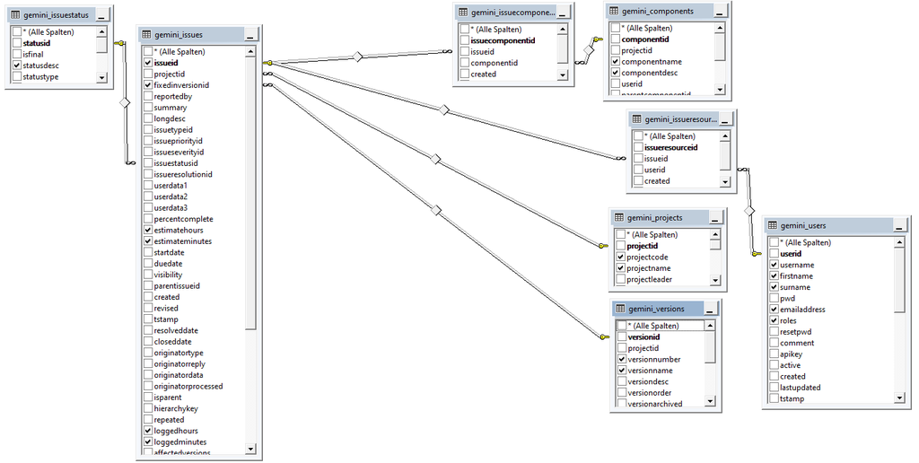

Abbildung 2: SQL-View (eigene Darstellung)

Dabei ergab die Prüfung der Attribute, dass weitere Kalkulationen erforderlich werden, da einige Attribute selbst oder Bestandteile dieser nicht zielkonform vorliegen und erst berechnet werden müssen. Die einzelnen Kalkulationen werden im Nachfolgenden separat ausgewiesen, begründet und erklärt.

Erstellung View

Zunächst galt es die View zu erstellen. Hierzu wurden die Kombination der gewünschten Spalten einzelner Tabellen (vgl. Tabelle 4) notwendig. In untenstehender Query wurde im SQL die Ansicht "SE_PowerBI" erzeugt (vgl. Code-Snippet 400). Die View dient als Ausgangslage, die Code-Snippets beziehen sich dabei immer auf den View. Es werden für den einfacheren Lesefluss zunächst die Code-Änderungen erläutert. Am Ende des Kapitels ist der finale Code zu entnehmen.

```python
# Code-Snippet 400
# Sprache: Structured Query Language
# -----------------------------------------------------------------------------------------------------

# 1. Erstellung der VIEW
USE [SE_Gemini_PROD]
GO

/****** Object: View [dbo].[SE_PowerBI] Script Date: 14.05.2023 14:28:25 ******/
SET ANSI_NULLS ON
GO

SET QUOTED_IDENTIFIER ON
GO

ALTER view [dbo].[SE_PowerBI]
AS

SELECT dbo.gemini_issues.fixedinversionid
, dbo.gemini_versions.versionnumber
, dbo.gemini_versions.versionname
, dbo.gemini_projects.projectcode
, dbo.gemini_projects.projectname
, dbo.gemini_issuestatus.statusdesc
, dbo.gemini_issues.issueid
, dbo.gemini_issues.estimatehours
, dbo.gemini_issues.estimateminutes
, dbo.gemini_issues.loggedhours
, dbo.gemini_issues.loggedminutes
, dbo.gemini_users.username
, dbo.gemini_users.firstname
, dbo.gemini_users.surname
, dbo.gemini_users.emailaddress
, dbo.gemini_users.roles
, dbo.gemini_components.componentname
, dbo.gemini_components.componentdesc
, dbo.gemini_issues.created
, dbo.gemini_issues.closeddate

FROM dbo.gemini_issues INNER JOIN
 dbo.gemini_issuestatus ON dbo.gemini_issues.issuestatusid = dbo.gemini_issuestatus.statusid INNER JOIN
 dbo.gemini_projects ON dbo.gemini_issues.projectid = dbo.gemini_projects.projectid INNER JOIN
 dbo.gemini_issuecomponents ON dbo.gemini_issues.issueid = dbo.gemini_issuecomponents.issueid INNER JOIN
 dbo.gemini_versions ON dbo.gemini_issues.fixedinversionid = dbo.gemini_versions.versionid INNER JOIN
 dbo.gemini_issueresources ON dbo.gemini_issues.issueid = dbo.gemini_issueresources.issueid INNER JOIN
 dbo.gemini_users ON dbo.gemini_issueresources.userid = dbo.gemini_users.userid INNER JOIN
 dbo.gemini_components ON dbo.gemini_issuecomponents.componentid = dbo.gemini_components.componentid
GO
```

Zielbetrachtung Z3 & Z3.1

In einem nächsten Schritt wurden die gekoppelten Ziele betrachtet:

Z3 - Performance Projekte

Z3.1 - Budgetüberschreitung

Die in der View geladenen Tabellen, verfügen über die geschätzten Stunden ("estimatedhours" sowie "estimatedminutes") in zwei separaten Spalten. Zwecks einfacher Vergleichbarkeit der Projekte sollten die Informationen in eine Variable überführt werden, gemäss Indikator (vgl. Tabelle 1) als Stunden.

Folglich galt es diese zu addieren und als neue Spalte abzubilden "calcEstimated". Dabei galt es zu beachten, dass die Minuten unweigerlich zu Dezimalzahlen führen, ergo musste der Datentyp FLOAT gesetzt werden, daher der Multiplikator *1.0 (vgl. Code-Snippet 410).

```python
# Code-Snippet 410
# Sprache: Structured Query Language
# -----------------------------------------------------------------------------------------------------

# Bildung Ersatzvariable geschätzter Stunden
, (dbo.gemini_issues.estimatehours * 1.0) + (dbo.gemini_issues.estimateminutes / 60.0) AS 'calcEstimated'
```

Im nächsten Schritt galt es dasselbe Prinzip für die gebuchten Stunden ("loggedhours" sowie "loggedminutes") vorzunehmen. Bereitgestellt wurde die Summen-Variable "calcLogged" (vgl. Code-Snippet 420).

```python
# Code-Snippet 420
# Sprache: Structured Query Language
# -----------------------------------------------------------------------------------------------------

# Bildung Ersatzvariable gebuchte Stunden
, (dbo.gemini_issues.loggedhours * 1.0)+(dbo.gemini_issues.loggedminutes / 60.0) AS 'calcLogged'
```

```python
# Code-Snippet 430
# Sprache: Structured Query Language
# -----------------------------------------------------------------------------------------------------

# Bildung Differenz SOLL-IST-Stunden
, ((dbo.gemini_issues.estimatehours,0.0) * 1.0) + ((dbo.gemini_issues.estimateminutes,0.0) / 60.0) - ((dbo.gemini_issues.loggedhours,0.0)* 1.0)+((dbo.gemini_issues.loggedminutes,0.0) / 60.0) AS 'calcDiffHours'
```

Nach einer schnellen Prüfung des Datensatz auf Basis der Kalkulationen von Code-Snippets 410 - 430 wurde ein Problem identifiziert. Es existieren Projekte bzw. Issues, welche zwar geschätzt, aber vom Kunden nie bestellt wurden. Ebenfalls möglich wären auch Issues, welche nicht sauber gepflegt wurden und entsprechend keine Zeiteingaben beinhalten. So wurde der Sachverhalt über die Abfrage nach "<> 0" verdeutlicht (vgl. Code-Snippet 440).

```python
# Code-Snippet 440
# Sprache: Structured Query Language
# -----------------------------------------------------------------------------------------------------

# Prüfung auf Null-Eintragungen
SELECT * FROM dbo.SE_PowerBI WHERE calcDiffHours <> 0.0
```

Die ursprünglichen Queries wurden in untenstehendem Code-Snippet mit der COALESCE-Funktion ergänzt (vgl. Code-Snippet 450).

```python
# Code-Snippet 450
# Sprache: Structured Query Language
# -----------------------------------------------------------------------------------------------------

# für calcEstimated
, (COALESCE(dbo.gemini_issues.estimatehours,0.0) * 1.0)+(COALESCE(dbo.gemini_issues.estimateminutes,0.0)/60.0) AS 'calcEstimated'

# für calcLogged
, (COALESCE(dbo.gemini_issues.loggedhours,0.0)* 1.0)+(COALESCE(dbo.gemini_issues.loggedminutes,0.0)/60.0) AS 'calcLogged'

# für calcDiffHours
, (COALESCE(dbo.gemini_issues.estimatehours,0.0) * 1.0)+(COALESCE(dbo.gemini_issues.estimateminutes,0.0) / 60.0) - (COALESCE(dbo.gemini_issues.loggedhours,0.0) * 1.0)+(COALESCE(dbo.gemini_issues.loggedminutes,0.0) / 60.0) AS 'calcDiffHours'
```

Zielbetrachtung Z1

In einem nächsten Schritt wurden die Attribute zum Ziel überprüft:

Z1 - Durchlaufzeit Projekt

Die Durchlaufzeit soll auf Basis der Differenz vom Abschluss- zum Eröffnungsdatum des Issues erfolgen. Da die Differenz im Datensatz nicht besteht, musste diese errechnet werden. Hierfür eignet sich die SQL-Funktion "Datediff, welche die Differenz auf Basis von Tagen ausgibt (Microsoft, 2023b). Es wurde dazu die Spalte "Durchlaufzeit" angelegt (vgl. Code-Snippet 460).

```python
# Code-Snippet 460
# Sprache: Structured Query Language
# -----------------------------------------------------------------------------------------------------

# Differenz in Tagen zwischen Erstelldatum und Abschlussdatum ausweisen
, Datediff(day, dbo.gemini_issues.created, dbo.gemini_issues.closeddate) AS 'Durchlaufzeit'
```

Zielbetrachtung Z2

In einem nächsten Schritt wurden die Attribute zum Ziel überprüft:

Z2 - Performance Mitarbeitende

Initial wurden die Tabellen in der SQL-View mit "INNER JOIN" verbunden. Dies erwies sich jedoch als hinderlich, da dies jeweils Datensätze ausschliesst in welchen dem Issue kein Mitarbeiter, Komponenten oder Version zugewiesen war. Entsprechend mussten die Beziehungen besser definiert werden. Da die Werte voneinander abhängig sind, wurde auf "LEFT OUTER JOIN [... ] ON" zurückgegriffen.

In untenstehendem Code-Snippet wurde die View entsprechend angepasst (vgl. Code-Snippet 470).

```python
# Code-Snippet 470
# Sprache: Structured Query Language
# -----------------------------------------------------------------------------------------------------

FROM   dbo.gemini_issues
       INNER JOIN dbo.gemini_issuestatus
               ON dbo.gemini_issues.issuestatusid =
                  dbo.gemini_issuestatus.statusid
       INNER JOIN dbo.gemini_projects
               ON dbo.gemini_issues.projectid = dbo.gemini_projects.projectid
       LEFT OUTER JOIN dbo.gemini_issuecomponents
                    ON dbo.gemini_issues.issueid =
                       dbo.gemini_issuecomponents.issueid
       LEFT OUTER JOIN dbo.gemini_versions
                    ON dbo.gemini_issues.fixedinversionid =
                       dbo.gemini_versions.versionid
       LEFT OUTER JOIN dbo.gemini_issueresources
                    ON dbo.gemini_issues.issueid =
                       dbo.gemini_issueresources.issueid
       LEFT OUTER JOIN dbo.gemini_users
                    ON dbo.gemini_issueresources.userid =
                       dbo.gemini_users.userid
       LEFT OUTER JOIN dbo.gemini_components
                    ON dbo.gemini_issuecomponents.componentid =
                       dbo.gemini_components.componentid
```

In untenstehenden Code-Snippets wurden die finalen Queries bereitgestellt, welche das Datenset mit notwendigen Anpassungen ausstattet, um die Belastbarkeit der Datengrundlage zielkonform zu ermöglichen.

Einerseits wurde die SQL-Querry direkt (vgl. Code-Snippet 480) und andererseits für die Verwendung im vorliegenden Jupyter Notebook (vgl. Code-Snippet 490) bereitgestellt.

```python
# Code-Snippet 480
# Sprache: Structured Query Language (View erstellt, deshalb hier Query)
# -----------------------------------------------------------------------------------------------------

# SQL-Abfrage in SQL
SELECT dbo.gemini_issues.fixedinversionid,
       dbo.gemini_versions.versionnumber,
       dbo.gemini_versions.versionname,
       dbo.gemini_projects.projectcode,
       dbo.gemini_projects.projectname,
       dbo.gemini_issuestatus.statusdesc,
       dbo.gemini_issues.issueid,
       dbo.gemini_issues.estimatehours,
       dbo.gemini_issues.estimateminutes,
       (COALESCE(dbo.gemini_issues.estimatehours, 0.0) * 1.0) + (COALESCE(dbo.gemini_issues.estimateminutes, 0.0) / 60.0) AS calcEstimated,
       dbo.gemini_issues.loggedhours,
       dbo.gemini_issues.loggedminutes,
       (COALESCE(dbo.gemini_issues.loggedhours, 0.0) * 1.0) + (COALESCE(dbo.gemini_issues.loggedminutes, 0.0) / 60.0) AS calcLogged,
       (COALESCE(dbo.gemini_issues.estimatehours, 0.0) * 1.0 ) + (COALESCE(dbo.gemini_issues.estimateminutes, 0.0) / 60.0 ) - (COALESCE(dbo.gemini_issues.loggedhours, 0.0) * 1.0) + (COALESCE(dbo.gemini_issues.loggedminutes, 0.0) / 60.0 ) AS calcDiffHours,
       dbo.gemini_users.username,
       dbo.gemini_users.firstname,
       dbo.gemini_users.surname,
       dbo.gemini_users.emailaddress,
       dbo.gemini_users.roles,
       dbo.gemini_components.componentname,
       dbo.gemini_components.componentdesc,
       dbo.gemini_issues.created,
       dbo.gemini_issues.closeddate,
       Datediff(day, dbo.gemini_issues.created, dbo.gemini_issues.closeddate) AS Durchlaufzeit,
       dbo.gemini_versions.versionid

FROM   dbo.gemini_issues
       INNER JOIN dbo.gemini_issuestatus
               ON dbo.gemini_issues.issuestatusid =
                  dbo.gemini_issuestatus.statusid
       INNER JOIN dbo.gemini_projects
               ON dbo.gemini_issues.projectid = dbo.gemini_projects.projectid
       LEFT OUTER JOIN dbo.gemini_issuecomponents
                    ON dbo.gemini_issues.issueid =
                       dbo.gemini_issuecomponents.issueid
       LEFT OUTER JOIN dbo.gemini_versions
                    ON dbo.gemini_issues.fixedinversionid =
                       dbo.gemini_versions.versionid
       LEFT OUTER JOIN dbo.gemini_issueresources
                    ON dbo.gemini_issues.issueid =
                       dbo.gemini_issueresources.issueid
       LEFT OUTER JOIN dbo.gemini_users
                    ON dbo.gemini_issueresources.userid =
                       dbo.gemini_users.userid
       LEFT OUTER JOIN dbo.gemini_components
                    ON dbo.gemini_issuecomponents.componentid =
                       dbo.gemini_components.componentid
```

```python
# Code-Snippet 490
# Sprache: python / Bash-Script
# -----------------------------------------------------------------------------------------------------

# SQL-Abfrage in Python
import pyodbc
print(pyodbc.drivers())
conn = pyodbc.connect('Driver=ODBC Driver 17 for SQL Server;'
                      'Server=20.56.61.152;'
                      'Database=SE_Gemini_Prod;'
                      'UID=adm-bina-bi;'
                      'PWD=Frühling2023;')

cursor = conn.cursor()
cursor.execute( 'SELECT dbo.gemini_issues.fixedinversionid,'
                'dbo.gemini_versions.versionnumber,'
                'dbo.gemini_versions.versionname,'
                'dbo.gemini_projects.projectcode,'
                'dbo.gemini_projects.projectname,'
                'dbo.gemini_issuestatus.statusdesc,'
                'dbo.gemini_issues.issueid,'
                'dbo.gemini_issues.estimatehours,'
                'dbo.gemini_issues.estimateminutes,'
                '(COALESCE(dbo.gemini_issues.estimatehours, 0.0) * 1.0) + (COALESCE(dbo.gemini_issues.estimateminutes, 0.0) / 60.0) AS calcEstimated,'
                'dbo.gemini_issues.loggedhours,'
                'dbo.gemini_issues.loggedminutes,'
                '(COALESCE(dbo.gemini_issues.loggedhours, 0.0) * 1.0) + (COALESCE(dbo.gemini_issues.loggedminutes, 0.0) / 60.0) AS calcLogged,'
                '(COALESCE(dbo.gemini_issues.estimatehours, 0.0) * 1.0 ) + (COALESCE(dbo.gemini_issues.estimateminutes, 0.0) / 60.0 ) - (COALESCE(dbo.gemini_issues.loggedhours, 0.0) * 1.0) + (COALESCE(dbo.gemini_issues.loggedminutes, 0.0) / 60.0 ) AS calcDiffHours,'
                'dbo.gemini_users.username,'
                'dbo.gemini_users.firstname,'
                'dbo.gemini_users.surname,'
                'dbo.gemini_users.emailaddress,'
                'dbo.gemini_users.roles,'
                'dbo.gemini_components.componentname,'
                'dbo.gemini_components.componentdesc,'
                'dbo.gemini_issues.created,'
                'dbo.gemini_issues.closeddate,'
                'Datediff(day, dbo.gemini_issues.created, dbo.gemini_issues.closeddate) AS Durchlaufzeit,'
                'dbo.gemini_versions.versionid'

                'FROM   dbo.gemini_issues'
                'INNER JOIN dbo.gemini_issuestatus'
                'ON dbo.gemini_issues.issuestatusid ='
                  'dbo.gemini_issuestatus.statusid'
                'INNER JOIN dbo.gemini_projects'
                'ON dbo.gemini_issues.projectid = dbo.gemini_projects.projectid'
                'LEFT OUTER JOIN dbo.gemini_issuecomponents'
                    'ON dbo.gemini_issues.issueid ='
                       'dbo.gemini_issuecomponents.issueid'
                'LEFT OUTER JOIN dbo.gemini_versions'
                    'ON dbo.gemini_issues.fixedinversionid ='
                       'dbo.gemini_versions.versionid'
                'LEFT OUTER JOIN dbo.gemini_issueresources'
                   'ON dbo.gemini_issues.issueid ='
                       'dbo.gemini_issueresources.issueid'
                'LEFT OUTER JOIN dbo.gemini_users
                    'ON dbo.gemini_issueresources.userid ='
                       'dbo.gemini_users.userid'
                'LEFT OUTER JOIN dbo.gemini_components
                    'ON dbo.gemini_issuecomponents.componentid ='
                       'dbo.gemini_components.componentid')

for i in cursor:
    print(i)
```

# **Step 4 - Presenting information**

Im vorliegenden Kapitel wird auf die Visualisierung der Daten gemäss Zielsetzung eingegangen. Für die Visualisierung wurde nach Absprache mit der Leuchter Software Engineering AG ein PowerBI-Modell erstellt, welches die Daten des aufgesetzten SQL-Server visualisiert. Die Ansichten werden als Walk-Through-Verfahren einzeln vorgestellt.

Teilweise wurden einzelne Code-Anpassungen (bzgl. SQL und PowerBI) erforderlich, welche am Ende des Kapitels erklärt werden.

**Seite - Übersicht**

Als Einstiegsseite im PowerBI dient die Seite "Übersicht" (vgl. Abbildung 3). Auf ihr wurde der gesamte, prognostizierte Workload nach den Bereichen der SE dargestellt. Die Bereiche bilden das organisationale Gefäss für die darin enthaltenen Projekte, welche wiederum in "Components" und "Versions" eingeteilt werden.

Zur Darstellung wurde auf eine TreeMap zurückgegriffen, welche visuell eine ungefähre Abschätzung des Workloads ermöglichen soll. Die dafür benötigte Datenbasis bilden die kumulierten geschätzten Stunden nach Projekte.

Zuzüglich wurde ein Mouse-Hover bereitgestellt, welche zum selektierten Bereich (bzw. Projekte) die geschätzten Stunden und die Kurzbezeichnung des Projekts (projectcode) visuell darstellt.

[figure not shown]

Abbildung 3: PowerBI - Übersicht (eigene Darstellung)

**Seite - Components**

Auf der zweiten Seite befindet sich die Übersicht zu den "Components" (vgl. Abbildung 4). Die Components bilden Bereiche eines Projektes ab. Sie separieren ein Projekt in logische Einheiten wie Module (Bentuzermodul, Kundenmodul) oder Layers (Frontend, Backend, Middleware). Das Visual ist dynamisch und enthält verschiedene Filter, welche in Wechselwirkung stehen. Die Filter und deren Kausalitäten werden jeweils in der untenstehenden Seitenbeschreibung nach Element erklärt.

[figure not shown]

Abbildung 4: PowerBI - Components, ohne Filter (eigene Darstellung)

*Header*

Oben links befindet sich der Header mit den Informationen zu Projekt, Component und die entsprechende Beschreibung der Component. Die Werte des Headers werden angezeigt, sobald eine Filtereinstellung auf der rechten Seite vorgenommen wird. Alle Elemente des Headers geben die Informationen als String zurück.

*Säulendiagramm*

Unten links befindet sich das Säulendiagramm. Wurde kein Filterkriterium gesetzt, zeigt dieses alle Components über alle Projekte an. Dabei werden jeweils die Komponenten pro Projekt gruppiert ausgewiesen, d. h. enthält ein Projekt mehrere Components, so werden diese mittels Aggregation über eine separate Summenbildung von geschätzten (calcEstimated) sowie geschrieben Daten (calcLogged) dargestellt. Das Säulendiagramm ist dynamisch. Mittels Mouse-Hover kann der Volltext-Name der Component als auch die zugehörigen, aggregierten Daten pro Säule angezeigt werden. Mit dem unteren Schieberegler kann das Projekt-Portfolio nach weiteren Components abgesucht werden (vgl. Abbildung 4). Mit dem linken Schieberegler lässt sich der Wertebereich (Y-Achse) des Säulendiagramms einstellen (vgl. Abbildung 5).

[figure not shown]

Abbildung 5: PowerBI - Components, mit Rastereinstellung (eigene Darstellung)

*Filter "Components nach Projekten"*

Oben rechts befindet sich ein Filter, mit welchen nach Projekten und ihren Components gesucht werden kann (vgl. Abbildung 6). Über eine Scrollbar auf der rechten Seite können die Projekte durchsucht werden. Über den zugehörigen Drop-Down Button in einem Projekt können zugehörigen, Components angezeigt und selektiert werden. Eine Mehrfachselektion ist möglich.

Sobald eine Selektion vorgenommen wurde, sind die Details zur Component ersichtlich. Im *Header* werden die Informationen der Selektion angezeigt, wurde eine Mehrfachauswahl getroffen, wird nur die erste Component eingeblendet. Im Weiteren ändert sich das *Säulen-Diagramm*. Dieses lädt die entsprechenden Daten der selektierten Components und weist diese separat aus. Es besteht die Möglichkeit mit dem Filter *Status Issue* zu verknüpfen (vgl. Abbildung 7). Zuzüglich ist nun die *Performance* und *Durchlaufzeit* sichtbar (vgl. Abbildung 6).

*Karte "Durchlaufzeit""*

Oben mittig befindet sich die Karte Durchlaufzeit. Sie gibt die durchschnittliche Differenz in Anzahl Tagen wieder, welche vom Erstelldatum des Issues (created) bis es geschlossen wurde (closed).

[figure not shown]

Abbildung 6: PowerBI - Components, nach Elementen (eigene Darstellung)

*Filter "Status Issue"*

Unten rechts befindet sich der Filter "Status Issue" (vgl. Abbildung 7), mit welchen nach dem Status der Issues gesucht und gefiltert werden. Dieser Filter ist grundsätzlich unabhängig, kann aber mit dem Filter *Components nach Projekten* kombiniert werden (vgl. Abbildung 7). Wurde keine Selektion im Filter *Components nach Projekten* getroffen, werden im genannten Filter die Projekte gemäss selektiertem *Status Issue* angezeigt und können selektiert werden.

[figure not shown]

Abbildung 7: PowerBI - Components, mit Issue Filter (eigene Darstellung)

*Performance*

Oben mittig befindet sich die Performance der Components (vgl. Abbildung 6). Für die Darstellung der Performance wurde auf ein Tachometer Visual zurückgegriffen. Der Tachometer ist ebenfalls dynamisch ausgelegt und richtet sich nach den selektierten Filterkriterien (vgl. Abbildung 6 & 7). Die Basis des Tachometers bilden ebenfalls die kumulierten Daten von den geschätzten (calcEstimated) und geschriebenen Stunden (calcLogged). Wurde eine Mehrfachauswahl getroffen, werden die Werte aggregiert dargestellt. Dabei bildet der hellrote Strich beim kumulierten geschätzten Zeitaufwand (calcEstimated) im Sinne eines Zielwertes, welcher nicht überschritten werden sollte. Die Füllfarbe des Tachometers bilden die kumulierten geschriebenen Stunden (calcLogged).

**Seite - Versions**

Auf der dritten Seite des PowerBI Cockpits befinden sich die "Versions" (vgl. Abbildung 8). Die Versions sind als Releases oder im agilen Kontext auch als Sprints zu verstehen. Die Versions bilden nebst den "Components" ebenfalls ein Gefäss für die Sammlung von Arbeitspaketen innerhalb eines Projektes, diese sind aber unabhängig von "Components". Auch sie enthalten analog der Seite *Components* die wesentlichen Informationen wie z.B. geschätzte Stunden, geschriebene Stunden, eine Kurzbeschreibung der Version und zugewiesene Mitarbeitende.

[figure not shown]

Abbildung 8: PowerBI - Versions, ohne Filter (eigene Darstellung)

*Elemente*

Die Elemente der Seite wurden zwecks einer direkten Vergleichbarkeit mit den Components identisch gehalten und wurden auch als solche ausgestaltet (vgl. Abbildung 9). Die Funktionsweisen der Filter wurden übernommen. Die Datengrundlage bilden ebenfalls die geschätzten Stunden (calcEstimated) und geschriebenen Stunden (calcLogged). Aufgrund der Analogie mit der Seite *Components* wurde auf eine Beschreibung der einzelnen Elemente verzichtet; Die hier vorliegenden Elemente können sinngemäss entnommen werden.

[figure not shown]

Abbildung 9: PowerBI - Versions, mit Filtereinstellungen (eigene Darstellung)